# Polling Place Changes in WI

> Note: Below are **election day** polling places. For early voting (October 20-30) and ballot drop box locations, go to [iwillvote.com](https://iwillvote.com/locate/?state=WI)

# Polling Places from the Wisconsin Elections Commission

```r
# UPDATE THIS IF A NEW FILE IS POSTED!
file <- "2020 General Election PPL RU List.xlsx"

official_locations <- readxl::read_xlsx(here::here("data", file))

date <- "8-11-2020"
```

This analysis uses the “2020 General Election PPL RU List.xlsx” data posted on 8-11-2020. Here are the current files posted on https://elections.wi.gov/node/6527:

```r
# polling locations posted on website
html <- read_html("https://elections.wi.gov/node/6527") %>%
  html_nodes("a")

files <- tibble(file = html_text(html),
                link = html_attr(html, "href")) %>%
  filter(str_detect(file, "xls|csv"))

kable(files) %>%
  kable_styling() %>%
  scroll_box()
```

| file | link |
| --- | --- |
| Polling Place List - 2020 Partisan Primary- UPDATED 3:30pm 8-11-2020.xlsx | https://elections.wi.gov/sites/elections.wi.gov/files/2020-08/PPL%202020%20Partisan%20Primary%202.xlsx |
| 2020 Partisan Primary Referendums 062520.xlsx | https://elections.wi.gov/sites/elections.wi.gov/files/2020-06/2020%20Partisan%20Primary%20Referendums%20062520.xlsx |

# Changes from the August Primary Election

```r
old_locations <- readxl::read_xlsx(here::here("data", "PPL 2020 Partisan Primary 2.xlsx")) %>%
  select(County, Muni, ReportingUnit, PollingPlaceName, PollingPlaceAddress, Longitude, Latitude)

# a function to split out wards
split <- function(ward){

  min = str_extract(ward, "[0-9]*") %>%
           as.numeric()

  max = str_extract(ward, "-[0-9]*") %>%
           as.numeric() %>% abs()

  full_seq(c(min,
             max),
           1) %>%
    str_c(collapse = ",")
}

# split out wards
split_wards <- . %>%
  mutate_if(is.character, str_to_upper) %>%
  mutate(ward = str_extract(ReportingUnit, "[1-9].*") %>%
           # split on commas in wards
           str_split(",")) %>%
  unnest(ward) %>%
  # remove any letters
  mutate(ward = ward %>% str_remove("[A-z]")) %>%
  # make a sequence of wards
  mutate(ward_seq = map_chr(ward, possibly(split, otherwise = NA)),
         ward = coalesce(ward_seq, ward) %>%
           str_split(",")) %>%
  unnest(ward) %>%
  mutate_if(is.character, str_to_title) %>%
  mutate(County = str_remove(County, " County")) %>%
  mutate(ReportingUnit = paste("Ward ", ward)) %>%
  ungroup() %>%
  select(-ward_seq)


# apply function to old and new polling locations
official <- official_locations %>% split_wards()
old <- old_locations %>% split_wards()

# diff between old and new polling locations
diff <- anti_join(official, old,
                  by = c("County", "Muni", "ReportingUnit",
                         "ward", "PollingPlaceAddress")) %>%
  left_join(old,
            by = c("County", "Muni", "ReportingUnit", "ward"),
            suffix = c(".General", ".Primary"))

# calculate the total and net number of changes
diff %<>%
  group_by(County)%>%
  mutate(changes = length(unique(PollingPlaceAddress.General)),
         net = changes - length(unique(PollingPlaceAddress.Primary)))

# simplify polling place names + addresses
diff %<>% mutate(General = str_c(PollingPlaceName.General,
                                 PollingPlaceAddress.General,
                                 sep = ", "),
                 Primary = str_c(PollingPlaceName.Primary,
                                 PollingPlaceAddress.Primary,
                                 sep = ", "))
```

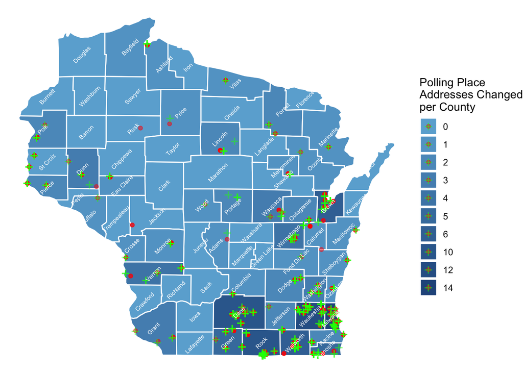

```r
wi <- map_data("county", "wisconsin") %>% mutate(County = str_to_title(subregion))

wi  %<>%
  # add total and net changes to map data
  left_join(diff %>%
              select(County, Muni, PollingPlaceAddress.General, changes, net) ) %>%
  # append polling location points
  full_join(diff %>% mutate(group = NA)) %>%
  mutate(changes = changes %>% replace_na(0),
         net = net %>% replace_na(0))

# plot changes
wi %>%
  group_by(subregion) %>%
  # Find the center of each subregion
  mutate(center_lat = mean(range(lat) ),
         center_long = mean(range(long) ) ) %>%
  ggplot( ) +
  aes(x = long, y = lat, group = group, fill = factor(changes)) +
  geom_polygon(color = "white") +
  geom_point(aes(x = Longitude.Primary,
                 y = Latitude.Primary),
             color = "Red", alpha = .5) +
  geom_point(aes(x = Longitude.General,
                 y = Latitude.General),
             color = "Green", shape = "+", size = 5, alpha = .5) +
  # label counties at their center
  geom_text( aes(x = center_long, y = center_lat, label = County),
             size = 2, angle = 45, check_overlap = T, color = "white") +
  theme_void() +
  labs(fill = "Polling Place\nAddresses Changed\nper County") +
  scale_fill_manual(values = colorRampPalette(c("#6BAED6", "#08306B"))(14))
```

New polling locations are green. Removed locations are red. Brighter points mean that more Wards moved to or from that polling location.

These data have a few errors. For example, red dots in Rusk and Jackson counties are the result of latitude or longitude typos, but these points are mostly correct. A few of these “changes” are the result of errors in the Elections Commission’s August file. For example, the polling location addresses for the Town of Dewey and Town of Sharon are simply incorrect in the August Primary Election file.

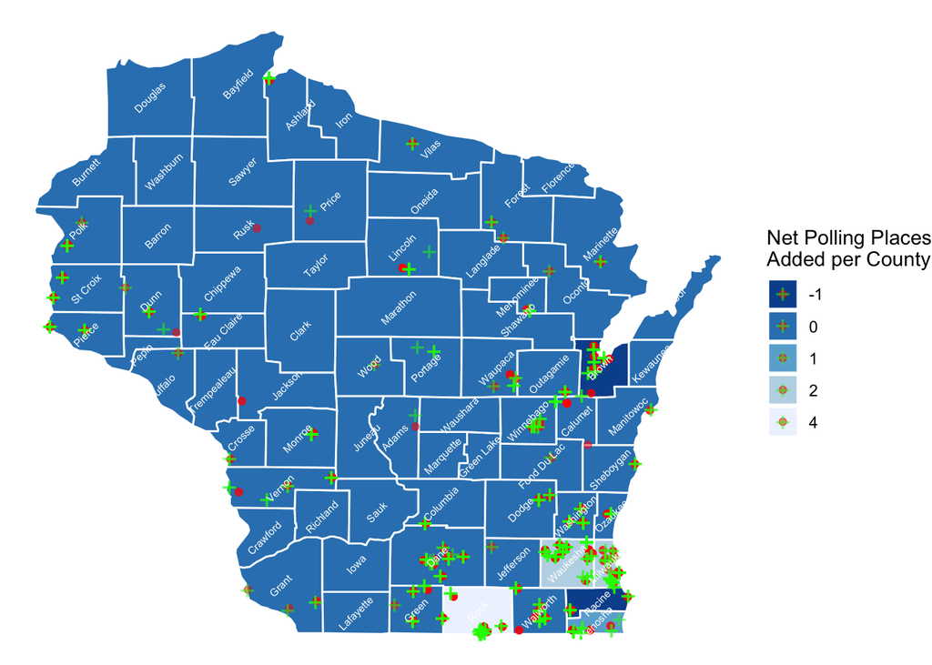

```r
# net
wi %>%
  group_by(subregion) %>%
  # Find the center of each subregion
  mutate(center_lat = mean(range(lat) ),
         center_long = mean(range(long) ) ) %>%
ggplot() +
  aes(x = long, y = lat, group = group, fill = factor(net)) +
  geom_polygon(color = "white") +
  geom_point(aes(x = Longitude.Primary,
                 y = Latitude.Primary),
             color = "Red", alpha = .5) +
  geom_point(aes(x = Longitude.General,
                 y = Latitude.General),
             color = "Green", shape = "+", size = 5, alpha = .5) +
  geom_text( aes(x = center_long, y = center_lat, label = County),
             size = 2, angle = 45, check_overlap = T, color = "white") +
  theme_void() +
  labs(fill = "Net Polling Places\nAdded per County") +
  scale_fill_brewer(direction = -1)
```

Green Bay (Brown County) and Burlington (Racine County) now have *fewer* polling places than they did for the August Primary election.

```r
# table of changes
diff %>%
  ungroup( ) %>%
  group_by(County, Muni, General, Primary) %>%
  summarise(Ward = paste(County, Muni, "Ward",
                         paste(ward, collapse = ", "),
                         sep = ", ")) %>%
  ungroup() %>%
  select(Ward, Primary, General) %>%
  distinct() %>%
  knitr::kable() %>%
  kable_styling() %>%
  scroll_box(height = "600px")
```

| Ward | Primary | General |
| --- | --- | --- |
| Adams, Town Of Colburn, Ward, 1 | Richfield Town Hall, 1602 County Road G, Coloma, Wi 54930 | Colburn Town Hall, 198 County Road C, Hancock, Wi 54943 |
| Ashland, City Of Ashland, Ward, 6, 7, 8, 9, 10, 11 | Wisconsin Indianhead Technical College-Ashland, 2100 Beaser Ave, Ashland, Wi 54806 | Bretting Community Center, 400 4th Ave W, Ashland, Wi 54806-1565 |
| Bayfield, City Of Ashland, Ward, 12 | Wisconsin Indianhead Technical College-Ashland, 2100 Beaser Ave, Ashland, Wi 54806 | Bretting Community Center, 400 4th Ave W, Ashland, Wi 54806-1565 |
| Brown, City Of De Pere, Ward, 13, 14, 15 | De Pere Community Center, 600 Grant St, De Pere, Wi 54115-1318 | Saint Mark Lutheran Church, 2066 Lawrence Dr, De Pere, Wi 54115-9421 |
| Brown, City Of De Pere, Ward, 6, 7, 8, 9, 18 | First United Presbyterian Church, 605 N Webster Ave, De Pere, Wi 54115-3430 | Swan Club, 875 Heritage Rd, De Pere, Wi 54115 |
| Brown, City Of Green Bay, Ward, 22, 23 | Curative Connections, 2900 Curry Ln, Green Bay, Wi 54311-5857 | Bay Beach Amusement Park, 1313 Bay Beach Rd, Green Bay, Wi 54302 |
| Brown, City Of Green Bay, Ward, 6, 7, 9, 14 | Danz Elementary School, 2130 Basten St, Green Bay, Wi 54302-3640 | Bay Beach Amusement Park, 1313 Bay Beach Rd, Green Bay, Wi 54302 |
| Brown, City Of Green Bay, Ward, 25, 36, 37, 39, 40 | Keller Elementary School, 1806 Bond St, Green Bay, Wi 54303-4604 | Johnsonville Tailgate Village, 1265 Lombardi Ave, Green Bay, Wi 54304 |
| Brown, Town Of Holland, Ward, 1, 2 | Holland Town Hall, 1671 Hill Rd, Greenleaf, Wi 54126 | Vanabel’s Of Hollandtown, 8108 County Road D, Kaukauna, Wi 54130 |
| Brown, Village Of Suamico, Ward, 1, 2, 3, 4, 5, 6, 7, 8 | Suamico Municipal Services Center, 12781 Velp Ave, Suamico, Wi 54313-8030 | Urban Edge (Previously The Marq Building, Next To Shopko), 2310 Lineville Rd, Suamico, Wi 54313 |
| Buffalo, Town Of Mondovi, Ward, 1 | Mondovi City Hall - Chambers, 156 S Franklin St, Mondovi, Wi 54755-1514 | Central Lutheran Church, 221 W Main St, Mondovi, Wi 54755 |
| Calumet, Village Of Harrison, Ward, 3, 4, 17, 18, 11, 12, 13 | Harrison Municipal Building, W5298 Hwy 114, Menasha, Wi 54952 | Waverly Beach, N8770 Firelane 1, Menasha, Wi 54952 |
| Columbia, City Of Lodi, Ward, 1, 2, 3, 4, 5, 6 | Lodi City Hall, 130 S Main St, Lodi, Wi 53555-1119 | United Methodist Church, 130 Locust, Lodi, Wi 53555 |
| Dane, City Of Fitchburg, Ward, 1, 2, 3, 4 | Marketplace Fire Station, 2931 Marketplace Dr, Fitchburg, Wi 53719 | Little John’s Restaurant, 5302 Verona Rd, Fitchburg, Wi 53711 |
| Dane, City Of Madison, Ward, 92 | Meadowridge Library, 5726 Raymond Rd, Madison, Wi 53711-4232 | Falk Elementary, 6323 Woodington Way, Madison, Wi 53711-3162 |
| Dane, City Of Madison, Ward, 99 | Huegel Elementary, 2601 Prairie Rd, Madison, Wi 53711-4156 | Heritage Congregational Church, 3102 Prairie Rd, Madison, Wi 53719-1578 |
| Dane, City Of Madison, Ward, 105, 107, 127, 150, 154 | Olson Elementary School, 801 Redan Dr, Verona, Wi 53593 | Holy Name Heights, 702 S High Point Rd, Madison, Wi 53719-3522 |
| Dane, City Of Madison, Ward, 33, 34 | Warner Park Shelter, 1625 Northport Dr, Madison, Wi 53704-2300 | Lakeview Lutheran Church, 4001 Mandrake Rd, Madison, Wi 53704 |
| Dane, City Of Madison, Ward, 7 | Lake Edge United Church Of Christ, 4200 Buckeye Rd, Madison, Wi 53716 | Messiah Lutheran Church, 5202 Cottage Grove Rd, Madison, Wi 53716 |
| Dane, City Of Madison, Ward, 79 | Sequoya Library, 4340 Tokay Blvd, Madison, Wi 53711-1567 | Odana Hills Golf Course, 4635 Odana Rd, Madison, Wi 53711-1333 |
| Dane, City Of Monona, Ward, 1, 2, 3, 4, 5 | Monona Community Center, 1011 Nichols Rd, Monona, Wi 53716-2530 | Saint Stephens Lutheran Church, 5700 Pheasant Hill Rd, Monona, Wi 53716-3118 |
| Dane, Town Of Cottage Grove, Ward, 1, 2, 4, 5, 7 | Cottage Grove Town Hall, 4058 County Road N, Cottage Grove, Wi 53527-9503 | Cottage Grove Town Garage, 4062 County Highway N, Cottage Grove, Wi 53527 |
| Dane, Village Of Oregon, Ward, 7, 8, 9, 10 | Oregon Village Hall - Community Room, 117 Spring St, Oregon, Wi 53575-1451 | Oregon Village Hall - Community Room, 103 N Alpine Pkwy, Oregon, Wi 53575-3109 |
| Dodge, City Of Mayville, Ward, 1, 2, 3, 4, 5, 6, 7, 8 | Mayville City Hall, 15 S School St, Mayville, Wi 53050-1656 | Mayville Park Pavilion, 475 Park St, Mayville, Wi 53050 |
| Dodge, Village Of Theresa, Ward, 1, 2, 3 | Theresa Elementary School, 422 S Milwaukee St, Theresa, Wi 53091 | Theresa Fire Department, 302 Depot Rd, Theresa, Wi 53091 |
| Dunn, City Of Menomonie, Ward, 3, 4, 5, 7 | Leisure Services Center, 1412 6th St E, Menomonie, Wi 54751-3331 | Uw Stout - Multi-Purpose Room #50, 220 13th Ave E, Menomonie, Wi 54751 |
| Dunn, Town Of Peru, Ward, 1 | Rock Creek Town Hall, N995 County Road H, Mondovi, Wi 54755-6823 | Peru Town Hall, E7209 160th Ave, Mondovi, Wi 54755 |
| Dunn, Village Of Downing, Ward, 1 | Luepke Cabinet Shop, 406 Main St, Downing, Wi 54734-9497 | Village Of Downing Village Hall, 402 Main St, Downing, Wi 54734 |
| Eau Claire, City Of Eau Claire, Ward, 10, 47, 54, 76 | Messiah Lutheran Church, 2015 N Hastings Way, Eau Claire, Wi 54703-1753 | Hope Lutheran Church, 2226 Eddy Ln, Eau Claire, Wi 54703 |
| Fond Du Lac, City Of Fond Du Lac, Ward, 28 | Eagles Club, 515 N Park Ave, Fond Du Lac, Wi 54935 | Lakeside Park Pavilion, 71 Promen Dr, Fond Du Lac, Wi 54935 |

[output cut: 103 more lines]

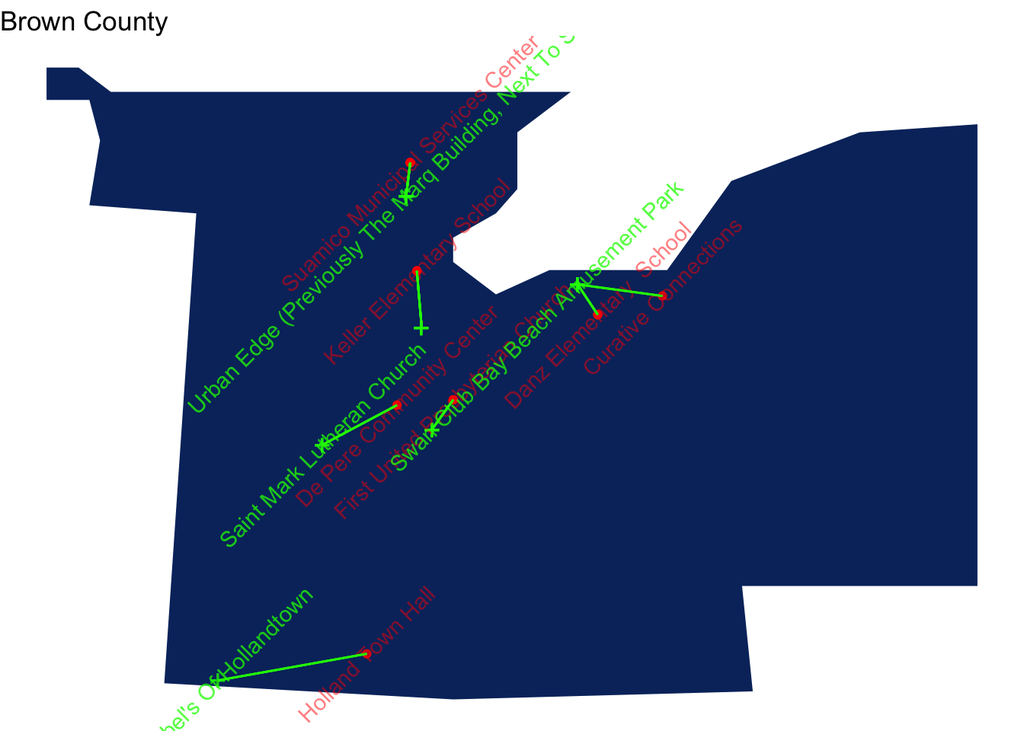

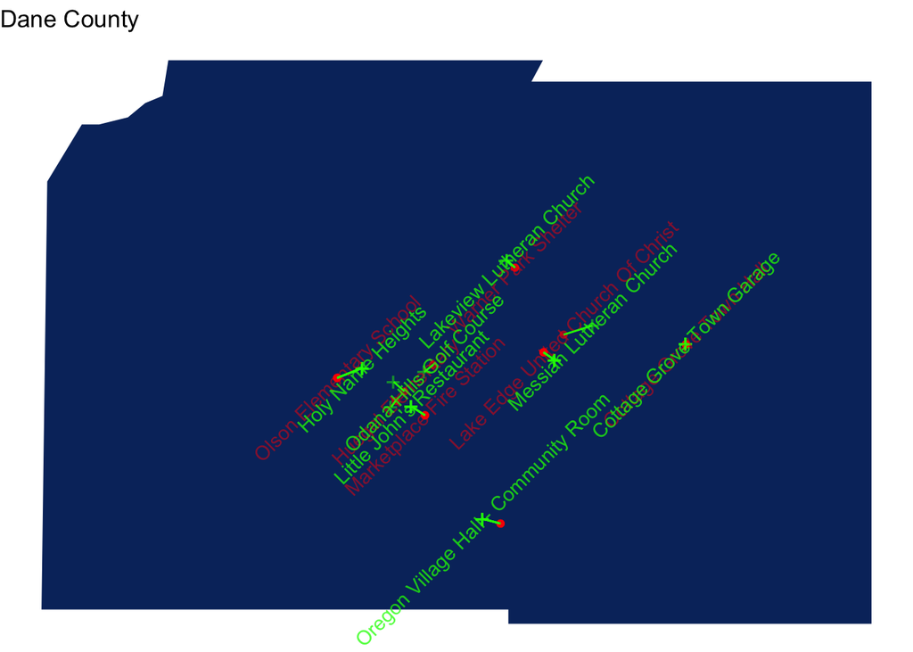

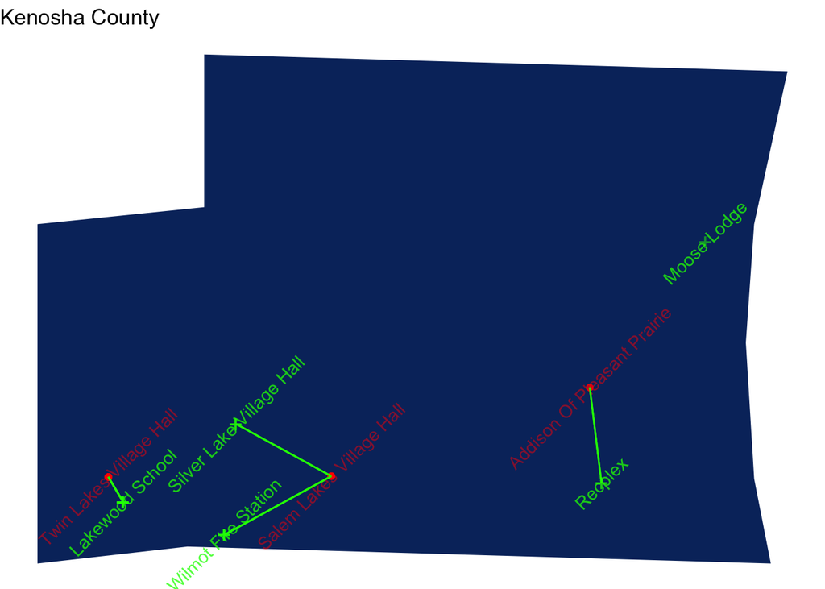

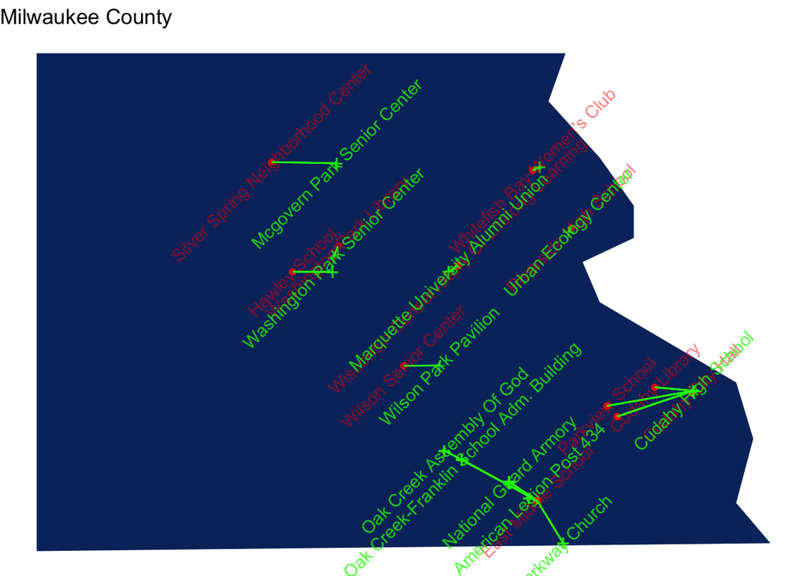

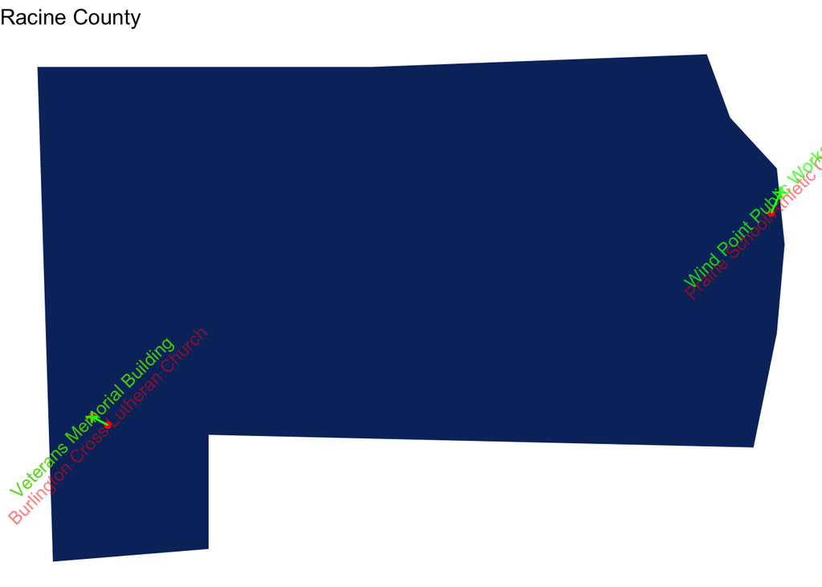

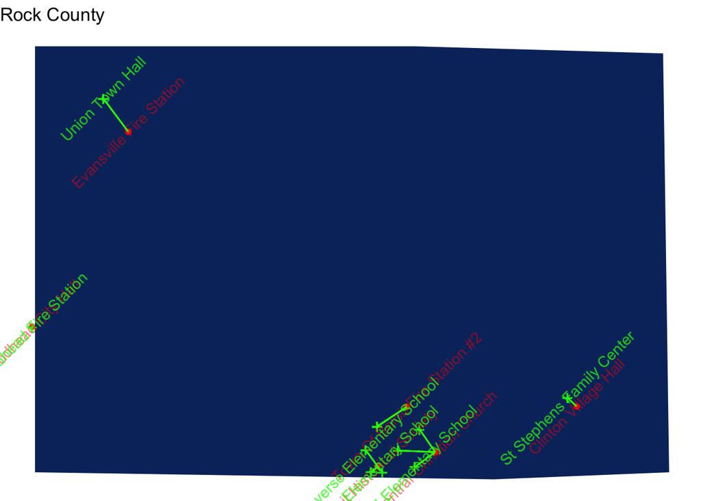

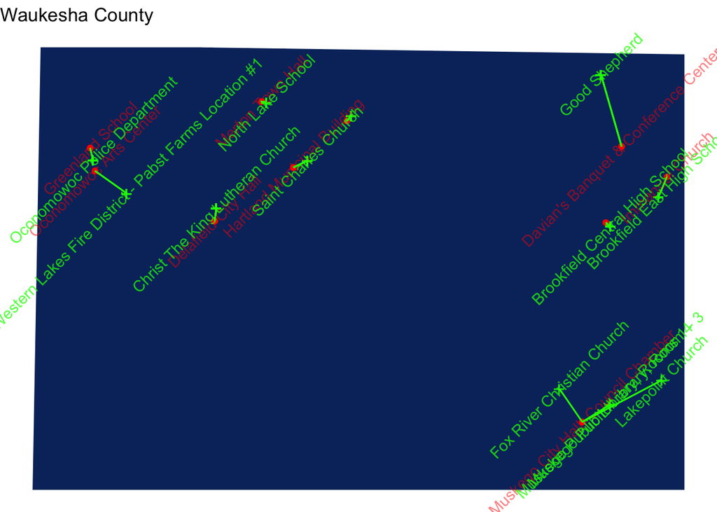

```r
# a function to plot each county
countymap <- function(county){
p <- wi %>%
  filter(County == county) %>%
ggplot() +
  geom_polygon(aes(x = long, y = lat, group = group), fill = "#08306B") +
  geom_point(aes(x = Longitude.Primary,
                 y = Latitude.Primary),
             color = "Red", alpha = .5) +
  geom_point(aes(x = Longitude.General,
                 y = Latitude.General),
             color = "Green", shape = "+", size = 5, alpha = .5) +
  geom_text( aes(x = Longitude.Primary,
                 y = Latitude.Primary,
                 label = PollingPlaceName.Primary),
             color = "Red", alpha = .5,
             angle = 45, check_overlap = T) +
    geom_text( aes(x = Longitude.General,
                 y = Latitude.General,
                 label = PollingPlaceName.General),
             color = "Green", alpha = .5,
             angle = 45, check_overlap = T) +
  geom_segment(aes(x = Longitude.Primary,
                   y = Latitude.Primary,
                   xend = Longitude.General,
                   yend = Latitude.General),
                #arrow = arrow(length = unit(0.1, "cm")),
               color = "green") +
  geom_text( aes(x = Longitude.General,
                 y = Latitude.General,
                 label = PollingPlaceName.General),
             color = "Green", alpha = .5,
             angle = 45, check_overlap = T) +
  theme_void() +
  labs(title = paste(county, "County"))

return(p)
}

map(diff %>%
      filter(net != 0 | changes > 6) %>%
      .$County %>% unique(),
    countymap)
```

# Polling place locations via Google Civic’s API

(Actually, it goes Wisconsin Elections Commission –> Voter Information Project –> Google Civic’s API)

To check that Google Civic is providing the same information that is posted on the Election Commission’s website, we can look up polling locations for addresses in each voting precinct using the Google Civic API.

```r
#########################################################
# one address per precinct
addresses <- read_csv(here::here("data", "wisconsin_example_addresses.csv"))

addresses %<>% mutate_if(is.character, str_to_upper)

addresses %<>% arrange(county_name)

# FIXME DELETE THIS WHEN API IS WORKING
addresses %<>% head(2)
# /FIXME
```

Polling locations are sometimes (in the days or weeks before an election) available via the Google Civic API, which uses data collected from states by the Voter Information Project, which notifies users when it posts data here: https://groups.google.com/g/vip-community

Notes about the Google Civic API (see the relevant documentation [here](https://developers.google.com/civic-information/docs/v2/elections/voterInfoQuery))  
- create an API key here: https://console.developers.google.com/apis/credentials  
- remember to authorize you API key  
- API calls should not need `electionId`; docs say it is optional  
- `pollingLocations` will not always be returned  
- may return a great deal more than polling locations (see Additional Google Civic API Contents below) - may return more than one polling place per input address as a list

```r
# make full street address
addresses %<>%
  mutate(voter_address = paste(voting_street_address,
                               voting_city,
                               state_code))

addresses$voter_address[1]
```

```
## [1] "1888 COUNTY ROAD Z ARKDALE WI"
```

Here is the polling place from the Google Civic API for the above address:

```r
# need to get AND authorize an API key
source(here::here("api_key.R"))

# A function to get poll addresses
get_poll <- function(voter_address){

  voter_address %<>%
    str_replace_all(" ", "%20") %>%
    str_remove_all(",")

  url <- str_c("https://civicinfo.googleapis.com/civicinfo/v2/voterinfo?address=",
               voter_address,
               "&returnAllAvailableData=true&key=",
               api_key)


  poll <- GET(url) %>%
    .$content %>%
    rawToChar() %>%
    fromJSON() %>%
    .$pollingLocations %>% # note: there is a lot more than this
    .$address %>%
    {ifelse(is.null(.), "NULL", .)}

  return(poll)
}


# test
get_poll(addresses$voter_address[1])
```

```
## [1] "NULL"
```

```r
# apply function to addresses
api_locations <- addresses %>%
  # "NULL" if NULL, "error" if any error
  mutate(PollingPlaceAddress = voter_address %>% map(possibly(get_poll, "error")))

# expand if there is more then one polling place per address
api_locations %<>% unnest(PollingPlaceAddress)

api_locations %>% select(voting_street_address, precinct_name, precinct_id, PollingPlaceAddress) %>%  kablebox()
```

| voting_street_address | precinct_name | precinct_id | PollingPlaceAddress |
| --- | --- | --- | --- |
| 1888 COUNTY ROAD Z | ADAMS - TOWN OF STRONGS PRAIRIE - WARD 003 | 1578843 | NULL |
| 150 W STATE ST | ADAMS - CITY OF ADAMS - WARD 004 | 418146 | NULL |

### API results not in the state’s xlsx file

```r
api_locations %>%
  filter(PollingPlaceAddress != "NULL") %>% # filter out API errors
  anti_join(official_locations) %>% # filter out locations already posted
  select(precinct_name, precinct_id, PollingPlaceAddress) %>%
  kablebox()
```

| precinct_name | precinct_id | PollingPlaceAddress |
| --- | --- | --- |

### Cases where Google Civic’s API did not return the same address when given polling locations

> Until the API is working, it will be all addresses. I’m just showing a few for now.

```r
official_locations %>%
  head() %>% #FIXME WHEN THE API IS WORKING
  mutate(PollingPlaceAddress_API = map(PollingPlaceAddress, get_poll)) %>% # get polling places for polling places' addresses
  filter(PollingPlaceAddress_API != PollingPlaceAddress) %>% # mismatches
  select(Muni, ReportingUnit, PollingPlaceName, PollingPlaceAddress, PollingPlaceAddress_API) %>%
  kablebox()
```

| Muni | ReportingUnit | PollingPlaceName | PollingPlaceAddress | PollingPlaceAddress_API |
| --- | --- | --- | --- | --- |
| CITY OF ADAMS | Wards 1-4 | ADAMS CITY HALL | 101 N MAIN ST, ADAMS, WI 53910-9805 | NULL |
| CITY OF WISCONSIN DELLS | Wards 5,9 | WISCONSIN DELLS MUNICIPAL BUILDING | 300 LA CROSSE ST, WISCONSIN DELLS, WI 53965-1568 | NULL |
| TOWN OF Adams | Wards 1-3 | ADAMS TOWN HALL | 1980 11TH AVE, FRIENDSHIP, WI 53934-9005 | NULL |
| TOWN OF Big Flats | Wards 1-2 | BIG FLATS TOWN HALL | 1104 COUNTY ROAD C, ARKDALE, WI 54613-9728 | NULL |
| TOWN OF Colburn | Ward 1 | COLBURN TOWN HALL | 198 COUNTY ROAD C, HANCOCK, WI 54943 | NULL |
| TOWN OF Dell Prairie | Wards 1-3 | DELL PRAIRIE TOWN HALL | 763 COUNTY ROAD K, WISCONSIN DELLS, WI 53965-8981 | NULL |

### Polling place addresses not returned by Google Civic’s API

> Until the API is working, it will be all addresses. I’m just showing a few for now.

```r
official_locations %>%
  head() %>% #FIXME WHEN THE API IS WORKING
  anti_join(api_locations) %>% # remove ones matched with API
  select(Muni, ReportingUnit, PollingPlaceName, PollingPlaceAddress) %>%
  kablebox()
```

| Muni | ReportingUnit | PollingPlaceName | PollingPlaceAddress |
| --- | --- | --- | --- |
| CITY OF ADAMS | Wards 1-4 | ADAMS CITY HALL | 101 N MAIN ST, ADAMS, WI 53910-9805 |
| CITY OF WISCONSIN DELLS | Wards 5,9 | WISCONSIN DELLS MUNICIPAL BUILDING | 300 LA CROSSE ST, WISCONSIN DELLS, WI 53965-1568 |
| TOWN OF Adams | Wards 1-3 | ADAMS TOWN HALL | 1980 11TH AVE, FRIENDSHIP, WI 53934-9005 |
| TOWN OF Big Flats | Wards 1-2 | BIG FLATS TOWN HALL | 1104 COUNTY ROAD C, ARKDALE, WI 54613-9728 |
| TOWN OF Colburn | Ward 1 | COLBURN TOWN HALL | 198 COUNTY ROAD C, HANCOCK, WI 54943 |
| TOWN OF Dell Prairie | Wards 1-3 | DELL PRAIRIE TOWN HALL | 763 COUNTY ROAD K, WISCONSIN DELLS, WI 53965-8981 |

```r
# align official and Google Civic API results
api_locations %<>% rename(County = county_name)

# reformat county
official_locations %<>%
  mutate_if(is.character, str_to_title) %>%
  mutate(County = str_remove(County, " COUNTY") )


locations <- full_join(official_locations, api_locations)
```

## Additional Google Civic API Contents

For reference, these values may or may not be returned:

```
"pollingLocations": [
    {
      "id": string,
      "address": {
        "locationName": string,
        "line1": string,
        "line2": string,
        "line3": string,
        "city": string,
        "state": string,
        "zip": string
      },
      "notes": string,
      "pollingHours": string,
      "name": string,
      "voterServices": string,
      "startDate": string,
      "endDate": string,
      "latitude": double,
      "longitude": double,
      "sources": [
        {
          "name": string,
          "official": boolean
        }
      ]
    }
  ],
  "earlyVoteSites": [
    {
      "id": string,
      "address": {
        "locationName": string,
        "line1": string,
        "line2": string,
        "line3": string,
        "city": string,
        "state": string,
        "zip": string
      },
      "notes": string,
      "pollingHours": string,
      "name": string,
      "voterServices": string,
      "startDate": string,
      "endDate": string,
      "latitude": double,
      "longitude": double,
      "sources": [
        {
          "name": string,
          "official": boolean
        }
      ]
    }
  ],
  "dropOffLocations": [
    {
      "id": string,
      "address": {
        "locationName": string,
        "line1": string,
        "line2": string,
        "line3": string,
        "city": string,
        "state": string,
        "zip": string
      },
      "notes": string,
      "pollingHours": string,
      "name": string,
      "voterServices": string,
      "startDate": string,
      "endDate": string,
      "latitude": double,
      "longitude": double,
      "sources": [
        {
          "name": string,
          "official": boolean
        }
      ]
    }
  ],
```